# Creating Stunning Charts with Datawrapper and Python

- Show All Code
- Hide All Code

An Overview

python

Author

Jesus L. Monroy

Published

Sep, 2024

Abstract

Datawrapper is a powerful online tool designed to help you create engaging and informative data visualizations. Whether you’re a journalist, researcher, or simply someone who wants to present data in a more visually appealing way, Datawrapper can make the process quick and easy.

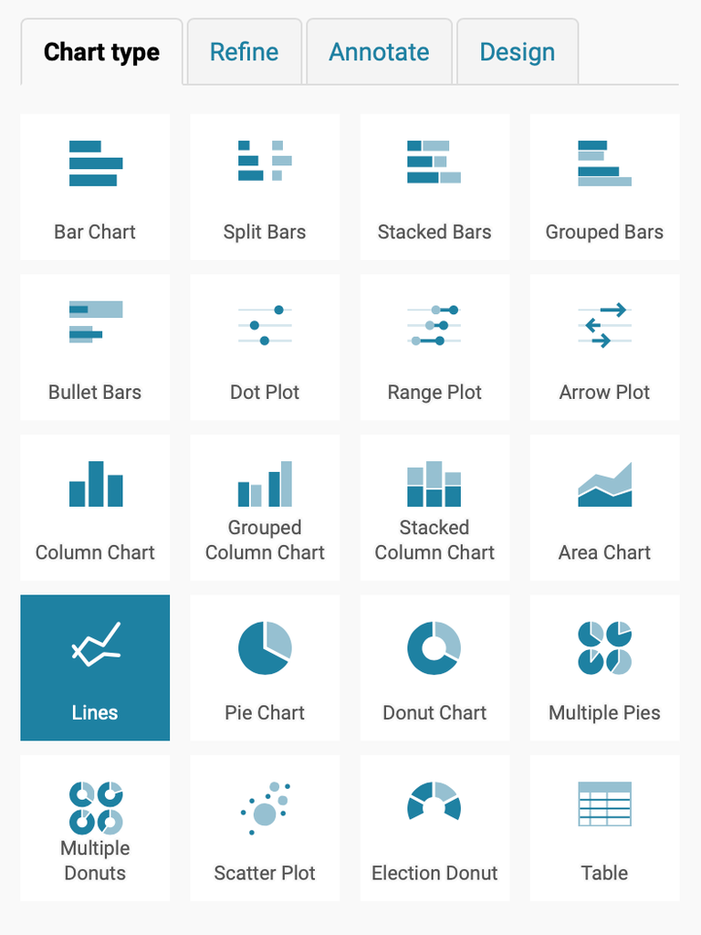

Figure 1: Datawrapper Charts Catalogue

## Key Features of Datawrapper

- **Easy-to-use interface**

Datawrapper’s intuitive design makes it accessible to users of all skill levels. Even those without a strong background in data visualization can create professional-looking charts and maps.

- **Diverse chart types**

From simple bar charts and line graphs to more complex maps and scatter plots, Datawrapper offers a variety of chart types to suit different data sets and storytelling needs.

- **Customization**

Users can customize their visualizations to match their brand or personal style. This includes options for changing colors, fonts, and layouts.

- **Interactivity**

Datawrapper allows users to create interactive visualizations that respond to user input. For example, users can hover over data points to see more detailed information or filter data based on specific criteria.

- **Embedding and sharing**

Once a visualization is created, it can be easily embedded into websites, blogs, or social media posts. Users can also share their visualizations directly with others.

- **Collaboration**

Datawrapper supports collaboration, allowing multiple users to work on the same visualization simultaneously. This is particularly useful for teams or organizations that need to create data visualizations together.

## Use Cases for Datawrapper

- **Journalism**

Datawrapper is a popular tool among journalists who want to present complex data in a clear and visually engaging way. It can be used to create interactive charts, maps, and infographics that enhance storytelling.

- **Research**

Researchers can use Datawrapper to visualize their findings and make them more accessible to a wider audience. By presenting data in a visual format, researchers can communicate their ideas more effectively and increase the impact of their work.

- **Business**

Businesses can use Datawrapper to create dashboards, reports, and presentations that help them make data-driven decisions. By visualizing key metrics and trends, businesses can gain valuable insights into their performance.

- **Education**

Teachers and students can use Datawrapper to create interactive visualizations that help them understand and learn from data. It can be used to teach data analysis, statistics, and other subjects.

### Visualization Types

Collection of available Datawrapper chart types and their IDs

Table 1: Datawrapper Chart Types

| Chart | TypeID |
| --- | --- |
| Bar Chart | `d3-bars` |
| Split Bars | `d3-bars-split` |
| Stacked Bars | `d3-bars-stacked` |
| Bullet Bars | `d3-bars-bullet` |
| Dot Plot | `d3-dot-plot` |
| Range Plot | `d3-range-plot` |
| Arrow Plot | `d3-arrow-plot` |
| Column Chart | `column-chart` |
| Grouped Column Chart | `grouped-column-chart` |
| Stacked Column Chart | `stacked-column-chart` |
| Area Chart | `d3-area` |
| Line Chart | `d3-lines` |
| Multiple Lines Chart | `multiple-lines` |
| Pie Chart | `d3-pies` |
| Donut Chart | `d3-donuts` |
| Multiple Pies | `d3-multiple-pies` |
| Multiple Donuts | `d3-multiple-donuts` |
| Scatter Plot | `d3-scatter-plot` |
| Election Donut | `election-donut-chart` |
| Table | `tables` |
| Choropleth Map | `d3-maps-choropleth` |
| Symbol Map | `d3-maps-symbols` |
| Locator Map | `locator-map` |

[More information](https://developer.datawrapper.de/docs/chart-types)

### Environment settings

```python
# Import libraries
from datawrapper import Datawrapper
import numpy as np
import pandas as pd
import polars as pl
import json
import warnings
warnings.filterwarnings('ignore')
```

```python
# Token gotten from datawrapper
filename = 'credentials.json'
# read json file
with open(filename) as f:
    keys = json.load(f)
# read credentials
token = keys['datawrapper_api']
```

```python
# Access datawrapper api
dw = Datawrapper(access_token = token)
```

### Datawrapper account

```python
# Check your account details
dw.get_my_account()
```

### Dataset

```python
# Read dataset courtesy of Sergio Sanchez
df = pd.read_csv(
    'https://raw.githubusercontent.com/chekos/datasets/master/data/datawrapper_example.csv',
    sep=";",
)
```

```python
# Select columns
df.columns = ['country','%pop in the capital','%pop in urban areas','%pop in rural areas']
```

```python
# Show dataframe
df
```

|  | country | %pop in the capital | %pop in urban areas | %pop in rural areas |
| --- | --- | --- | --- | --- |
| 0 | Iceland (Reykjavík) | 56.02 | 38.0 | 6.0 |
| 1 | Argentina (Buenos Aires) | 34.95 | 56.6 | 8.4 |
| 2 | Japan (Tokyo) | 29.52 | 63.5 | 7.0 |
| 3 | UK (London) | 22.70 | 59.6 | 17.7 |
| 4 | Denmark (Copenhagen) | 22.16 | 65.3 | 12.5 |
| 5 | France (Paris) | 16.77 | 62.5 | 20.7 |
| 6 | Russia (Moscow) | 8.39 | 65.5 | 26.1 |
| 7 | Niger (Niamey) | 5.53 | 12.9 | 81.5 |
| 8 | Germany (Berlin) | 4.35 | 70.7 | 24.9 |
| 9 | India (Delhi) | 1.93 | 30.4 | 67.6 |
| 10 | USA (Washington, D.C.) | 1.54 | 79.9 | 18.6 |
| 11 | China (Beijing) | 1.40 | 53.0 | 45.6 |

### Create stackbar chart

```python
# Create Datawrapper bar chart
pop = dw.create_chart(
    title='Where do people live?', chart_type='d3-bars-stacked', data=df
)
```

### Update chart description

```python
dw.update_description(
    pop['id'],
    source_name = 'UN Population Division',
    source_url = 'https://population.un.org/wup/',
    byline = 'Jesus L. Monroy<br>Economist & Data Scientist<br><br>',
    intro = 'Population percentage living in the capital by Country'
)
```

### Publish chart

```python
dw.publish_chart(chart_id = pop['id'])
```

### Customize metadata

```python
dw.update_chart(
    chart_id = pop['id'],
    metadata = {
        'visualize': {
            'sharing': {'enabled': True},
            'thick': True,
            'custom-colors': {
                '%pop in rural areas': '#dadada',
                '%pop in urban areas': '#1d81a2',
                '%pop in the capital': '#15607a',
               },
           },
        'publish': {
            'blocks': {'get-the-data': False},
           },
    }
)
```

### Republish chart

```python
dw.publish_chart(pop['id'])
```

## Display interactive chart

[interactive chart not shown]

Figure 2: Datawrapper Interactive Chart

**Note**

You can hover over the bars on the above chart to get dynamic results.

## Conclusions

To start using Datawrapper, simply create a free account on their website. Once you’re logged in, you can begin creating your first visualization.

Datawrapper offers a variety of tutorials and resources to help you get started and make the most of the platform.

By leveraging the power of Datawrapper, you can create compelling data visualizations that help you tell your story more effectively.

Whether you’re a seasoned data analyst or just starting out, Datawrapper is a valuable tool that can help you bring your data to life.

## References

- Datawrapper (2024) [Barcharts](https://academy.datawrapper.de/) in Datawrapper Academy
- Khanchandani E. (2020) [How to use Datawrapper for journalists](https://www.interhacktives.com/2020/01/29/data-visualisation-with-datawrapper-for-journalists-a-tutorial/) in Interhacktives
- Sanchez, S. (2023) [A lightweight Python wrapper for the Datawrapper API](https://datawrapper.readthedocs.io/en/latest/) in Datawrapper API

## Contact

**Jesus L. Monroy**  
*Economist & Data Scientist*

[Medium](https://medium.com/@jesuslm) | [Linkedin](https://www.linkedin.com/in/j3sus-lm) | [Twitter](https://x.com/j3suslm)